# Introduction to mapping with R

Ruth Kelly

9 October 2018

## TCD R-users group notes and code

### Introduction to mapping in R

#### Notes and code by Ruth Kelly with 09/10/2018

The aim of this code file is to introduce you to some of the basic file types, formats and packages for working with spatial data in R.

It is by no means comprehensive and there are many many more packages out there, but hopefully this will help to get started and understand the structure of spatial data files both in R and elsewhere.

### The two main types of map files

1. Shape/vector files (.shp etc)
   - Points
   - Lines
   - Polygons  
     Representations of categorical data and objects.

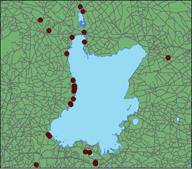

Lough neagh

2. Raster files (.ra, .asc)
   - Pixel images

For continous data, best for map algebra and modelling.

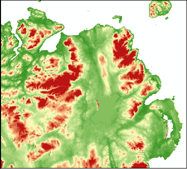

#### Part 1. Shape/vector files

Fundamentally, in my mind at least, geospatial modelling is all about the relationships between objects based on their locations. So the most importnat thing in any spatial dataset is knowing where objects are located in space (and therefore relative to one another).

To illustrate this let’s load in some data from a standard spreadsheet format, and turn it into map/spatial data using the function ‘coordinates’ in the package ‘sp’

#### Loading in your own field data, from spreadsheet format.

```r
### read in your data file as from .csv or text file as usual.
## e.g.

all_sites_year1 <- read.csv("all_sites_year2.csv")

### view this to see if it has loaded properly
summary(all_sites_year1)
```

```
##    x_coordina       y_coordina                  Site           Habitat
##  Min.   :202291   Min.   :323422   Cuilcagh       :18   Blanket bog:12
##  1st Qu.:249799   1st Qu.:326886   Eastern Mournes:34   Bog        :68
##  Median :251525   Median :344904   Gleenasheevar  :11   Dry heath  :22
##  Mean   :274196   Mean   :357528   Mullaghcarn    :20   Wet heath  :19
##  3rd Qu.:332603   3rd Qu.:380610   Slievanorra    :19   Wet Heath  : 1
##  Max.   :336314   Max.   :430449   Slieve beagh   :20
##
##  Burnt    point_code    Full_code   site_code      long
##  N:53   103    :  2   CH252  :  1   CH:18     Min.   :-7.965
##  Y:69   121    :  2   CH253  :  1   EM:34     1st Qu.:-7.234
##         122    :  2   CH256  :  1   GR:11     Median :-7.202
##         23     :  2   CH257  :  1   MN:20     Mean   :-6.856
##         24     :  2   CH265  :  1   SA:19     3rd Qu.:-5.971
##         5      :  2   CH270  :  1   SH:20     Max.   :-5.914
##         (Other):110   (Other):116
##       lat
##  Min.   :54.14
##  1st Qu.:54.17
##  Median :54.35
##  Mean   :54.46
##  3rd Qu.:54.67
##  Max.   :55.11
##
```

```r
head(all_sites_year1)
```

```
##   x_coordina y_coordina     Site     Habitat Burnt point_code Full_code
## 1     215293     331048 Cuilcagh Blanket bog     N        252     CH252
## 2     215291     331351 Cuilcagh Blanket bog     N        253     CH253
## 3     215282     332242 Cuilcagh Blanket bog     N        256     CH256
## 4     215287     332541 Cuilcagh Blanket bog     N        257     CH257
## 5     215603     330747 Cuilcagh Blanket bog     N        265     CH265
## 6     215590     332248 Cuilcagh Blanket bog     N        270     CH270
##   site_code   long    lat
## 1        CH -7.766 54.228
## 2        CH -7.766 54.231
## 3        CH -7.766 54.239
## 4        CH -7.766 54.242
## 5        CH -7.762 54.225
## 6        CH -7.762 54.239
```

```r
class(all_sites_year1)
```

```
## [1] "data.frame"
```

```r
### Turn this into a SpatialPointsDataFrame,
## using the function ' coordinates'in the package 'sp'
## You do this by 'telling' R which columns in the dataframe contain the
## coordinate locations.

### The objects after the <- are the names of the columns containing the
### coordinate data in the dataframe.
### Don't forget the ~ symbol after the  <-

coordinates(all_sites_year1) <- ~ x_coordina + y_coordina
class(all_sites_year1)
```

```
## [1] "SpatialPointsDataFrame"
## attr(,"package")
## [1] "sp"
```

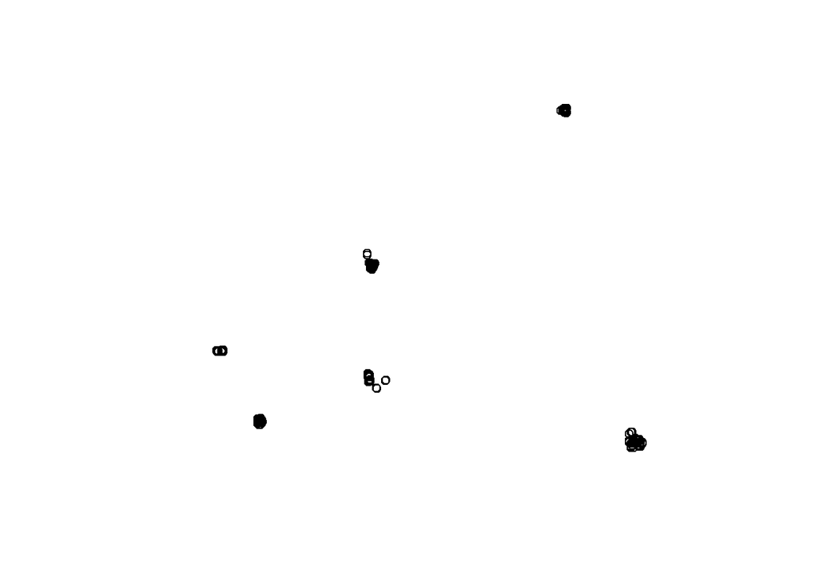

```r
## all_sites_year1 is now a spatial file, class = sp

### Note that when we plot this R automatically plots the coordinate columns.
plot(all_sites_year1, pch = 1)
```

The other common format in which you will recieve vector/shape files is as esri shapefiles. These are not a single file, but a collection of files representing different aspects of the map. Have a look in the file folder here to see all the files associated with a single map showing the counties of Northern Ireland (ni_counties.shp etc.)

The functions ‘readOGR’ and ‘writeOGR’ let you read and write Esri shapefiles for compatibility ArcView (in package ‘rgdal’)

Files in this format can be read in with the following code chunk

```r
counties <- readOGR(dsn = ".", layer = "ni_counties")
```

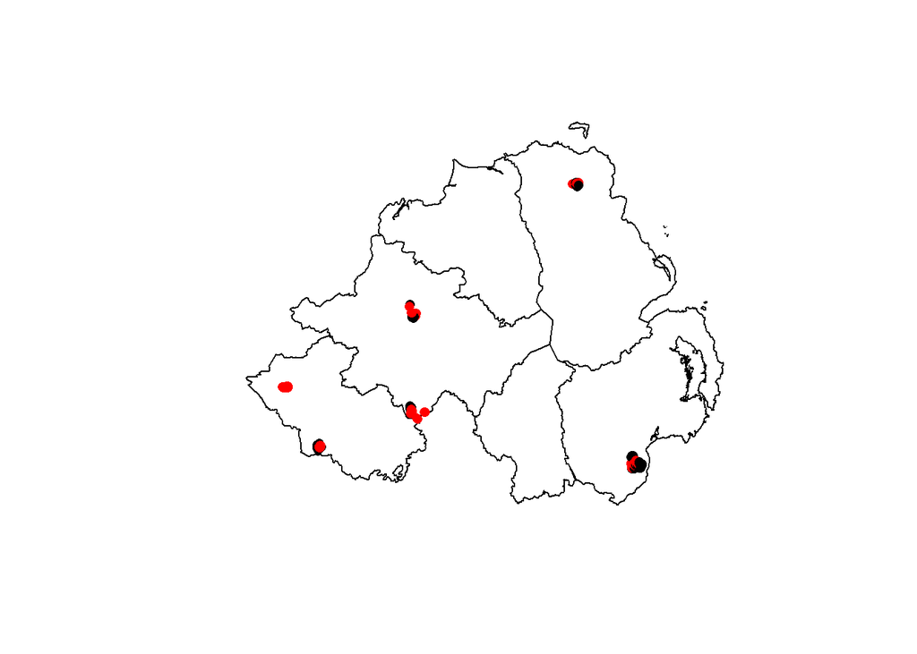

```r
#### plot these

plot(counties)

plot(all_sites_year1, col = all_sites_year1$Burnt, pch = 16, add = T)
```

A vector or shapefile is a complex object with various components the most important of which are + the data + the coordinate system + the boundary box

We access these elements using the @ symbol as follows.

```r
class(all_sites_year1)
```

```
## [1] "SpatialPointsDataFrame"
## attr(,"package")
## [1] "sp"
```

```r
### the dataset
head(all_sites_year1@data)
```

```
##       Site     Habitat Burnt point_code Full_code site_code   long    lat
## 1 Cuilcagh Blanket bog     N        252     CH252        CH -7.766 54.228
## 2 Cuilcagh Blanket bog     N        253     CH253        CH -7.766 54.231
## 3 Cuilcagh Blanket bog     N        256     CH256        CH -7.766 54.239
## 4 Cuilcagh Blanket bog     N        257     CH257        CH -7.766 54.242
## 5 Cuilcagh Blanket bog     N        265     CH265        CH -7.762 54.225
## 6 Cuilcagh Blanket bog     N        270     CH270        CH -7.762 54.239
```

```r
### the coordinate system

all_sites_year1@proj4string
```

```
## CRS arguments: NA
```

```r
### boundary box

all_sites_year1@bbox
```

```
##               min    max
## x_coordina 202291 336314
## y_coordina 323422 430449
```

#### Plotting shapefiles

For these examples I am using a dataset called vulgaris from the package ‘GISTools’ This dataset contains maps of the US and data on the phenology of the lilac Syringa Vulgaris.

Some other useful R library sources of premade maps include: mapdata, maps, rworldmaps

```r
# Read in the data - note this loads 4 objects
data(vulgaris)

class(vulgaris)
```

```
## [1] "SpatialPointsDataFrame"
## attr(,"package")
## [1] "sp"
```

```r
class(us_states)
```

```
## [1] "SpatialPolygonsDataFrame"
## attr(,"package")
## [1] "sp"
```

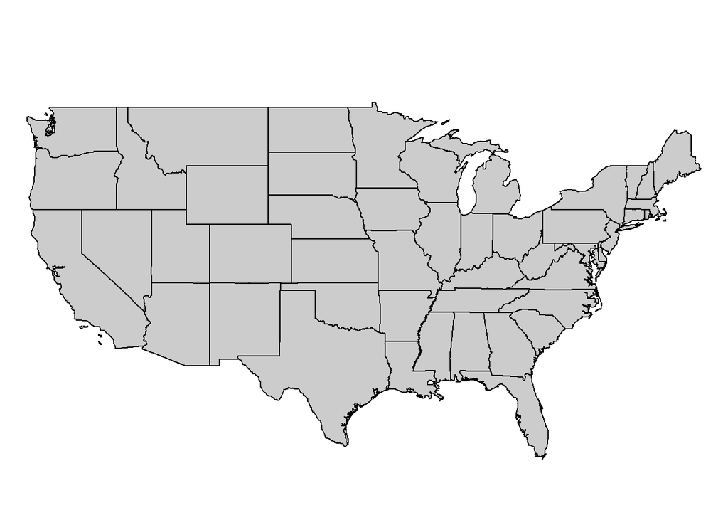

```r
### reset the margins to make plot bigger.
par(mar = c(0,0,2,0))

#### add colour
plot(us_states, col = "grey80")
```

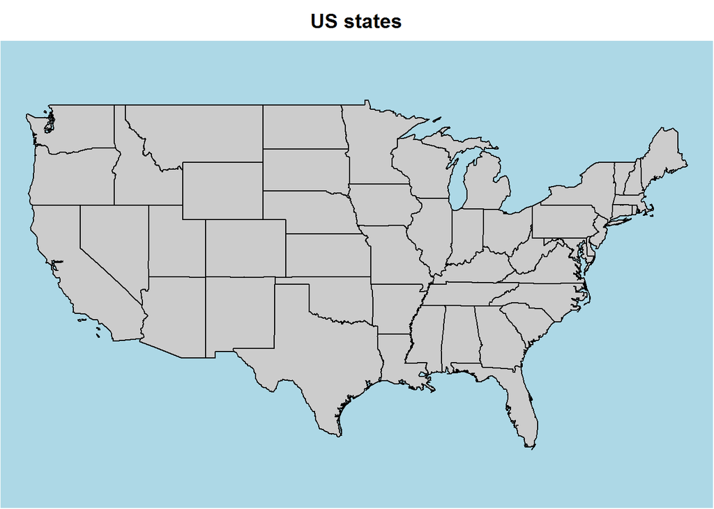

```r
### change background colour

plot(us_states, col = "grey80", bg = "light blue")

####  Add title
title("US states")
```

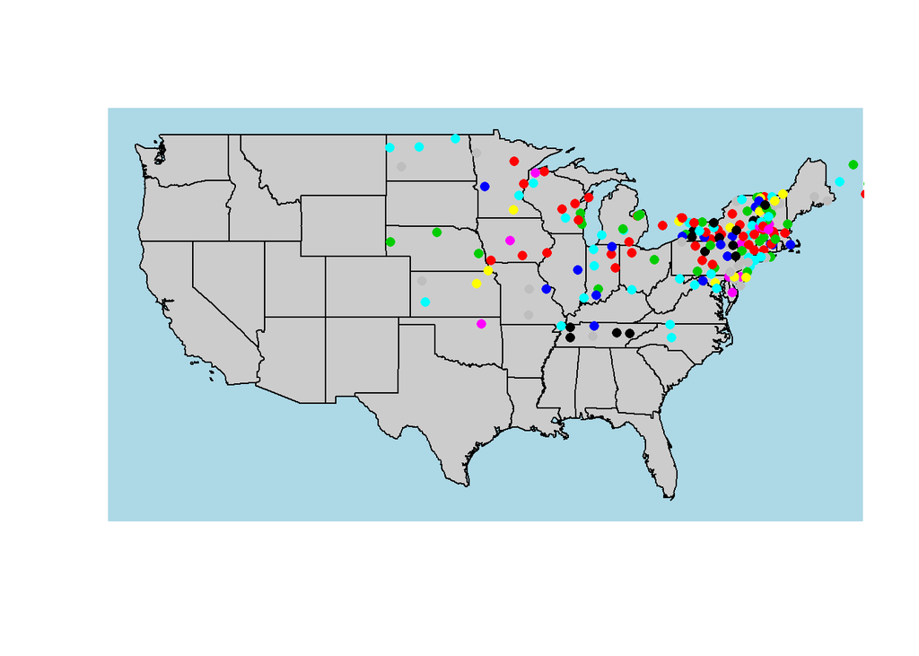

```r
### Just set the argument add = T in the plot function.

## eg point data from vulgaris

plot(us_states, col = "grey80", bg = "light blue")
### You can change colours of points etc. by calling the columns in the dataset
### just like in base R
plot(vulgaris, pch = 16, col = vulgaris$Year, add = T)
```

Plotting using data attributes of polygons - Choropleths!

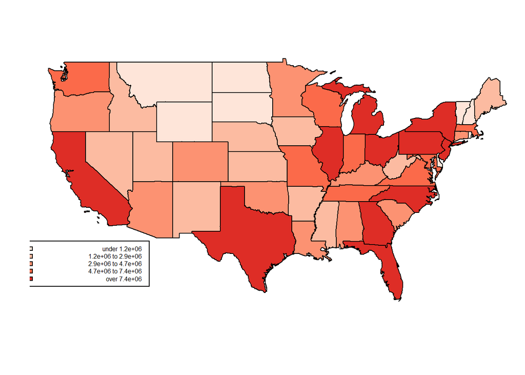

```r
##### Note: colours here are coming from the RColourBrewer package
### reset the margins to make plot bigger.
par(mar = c(3,2,2,0))

### set colours for your population plot data

cols1 <- auto.shading(us_states$POP1997, cols = brewer.pal(6,"Reds"))

### plot with test new colours..

choropleth(us_states, us_states$POP1997, shading = cols1)

### add legend
choro.legend(-128, 31, cols1, cex = 0.5)
```

#### Part 2. Rasters

Most often you’ll be downloading rasters created by other people, these are easily accessible online and commonly available examples include climate, altitude and human impact (see .ppt file in this folder for some of my favourite resources).

The standard map format is ‘.asc’ You can read this in using the function ‘readAsciiGrid’ in the package ‘maptools’

.tif and .ra files are also common and can be read into R directly as rasters using the function raster in the package ‘raster’

```r
alt1 <- readAsciiGrid("alt1_test.asc")
class(alt1)
```

```
## [1] "SpatialGridDataFrame"
## attr(,"package")
## [1] "sp"
```

```r
#### Note that this is now a Spatial Grid dataframe and has similar attributes to the shapefiles above
# alt1@bbox
# alt1@proj4string
# summary(alt1@data)


### Make this a raster for plotting reasons

alt2 <- raster(alt1)
class(alt2)
```

```
## [1] "RasterLayer"
## attr(,"package")
## [1] "raster"
```

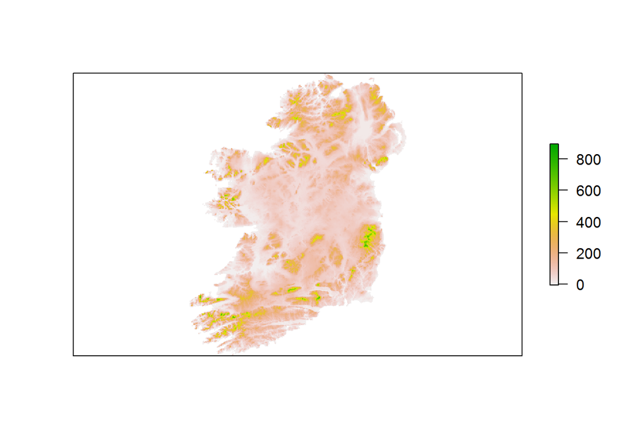

```r
### the most intuitive plotting is achieved
## image(alt2)

## Or simply
plot(alt2, yaxt = "n", xaxt = "n")
```

```r
# to add points..
#plot(all_sites_year1, add = T, pch = 16)

### Hint the function extract in the package raster takes the values from a raster file
### and adds them to points in another file.

#sites_with_altitude <- extract(x = alt2, y = all_sites_year1, sp = TRUE)
#names(sites_with_altitude)
```

For anyone interested in climate data you may enjoy accessing the bioclim global climate datasets directly from R using the function ‘getData’ in the package ‘raster’ (from http://www.worldclim.org/bioclim)

e.g. world_clim1 <- getData(“worldclim”,var=“bio”,res=10)

Just please don’t do this on github because it’ll go way over my space limits.

I hope you find these code snippets useful for getting started.

Best regards and happy mapping.